# Kaggle_Top100

# Efficient Market Hypothesis

The efficient-market hypothesis (EMH) stipulates that you can't, on average, "beat the market" by picking better stocks or timing the market. According to the EMH, all information about the market is immediately available to every market participant in one form or another, and it is immediately reflected in asset prices, so investing is like playing a game of cards with all the cards revealed. The only way you can win is by betting on very risky stocks and getting lucky. The French mathematician Bachelor developed a test for the EMH around 1900. The test examines consecutive occurrences of negative and positive price changes. We don't count events during which the price didn't change and only use them to end a run. These types of events are relatively rare anyway for liquid markets.

```python
emh_test_data = crypto.iloc[:,:5]
```

```python
def count_runs(signs):
    nruns = 0
    prev = None
    for s in signs:
        if s != 0 and s != prev:
            nruns += 1
        prev = s
    return nruns
```

```python
def proc_runs(close):
    diffs = np.diff(emh_test_data[close])
    nplus = (diffs > 0).sum()
    nmin = (diffs < 0).sum()
    n = nplus + nmin
    mean = (2 * (nplus * nmin) / n) + 1
    var = (mean - 1) * (mean - 2) / (n - 1)
    std = np.sqrt(var)
    signs = np.sign(diffs)
    nruns = count_runs(np.diff(signs))
    return mean, std, (nruns - mean) / std
```

```python
means = []
stds = []
zscores = []
for symbol in emh_test_data.columns:
    mean, std, zscore = proc_runs(symbol)
    means.append(mean)
    stds.append(std)
    zscores.append(zscore)
```

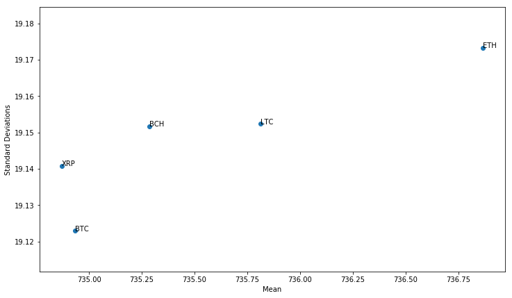

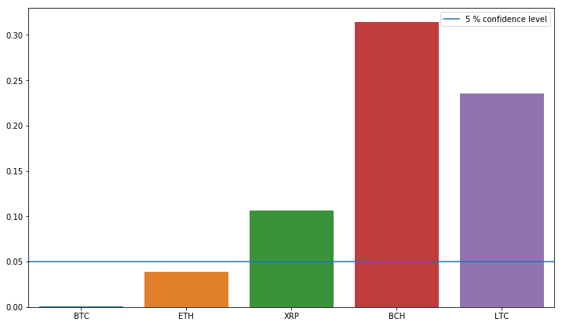

```python
plt.figure(figsize=(12,7))
plt.scatter(means,stds)
plt.xlabel('Mean')
plt.ylabel('Standard Deviations')
for i in range(len(emh_test_data.columns)):
    plt.annotate(emh_test_data.columns[i],xy=(means[i],stds[i]))
plt.show()
plt.figure(figsize=(12,7))
sns.barplot(x=emh_test_data.columns,y= 1 - norm.cdf(np.abs(zscores)))
plt.axhline(0.05, label='5 % confidence level')
plt.legend()
plt.show()
```

```python
print('Following shows the probability of the EMH for different crypto-currency: ')
probs = pd.DataFrame(1 - norm.cdf(np.abs(zscores)),columns=['Probabilities'],index=emh_test_data.columns)
probs.sort_values(by='Probabilities',ascending=False)
```

```
Following shows the probability of the EMH for different crypto-currency:
```

|  | Probabilities |
| --- | --- |
| BCH | 0.313862 |
| LTC | 0.235409 |
| XRP | 0.106179 |
| ETH | 0.038680 |
| BTC | 0.000600 |

# Predictive Models

```python
print('From the Crypto Currency given below,Enter the one you want to predict: ')
print(crypto.columns.values)
symbolic = input('Enter a crypto currency ')
```

```
From the Crypto Currency given below,Enter the one you want to predict:
['BTC' 'ETH' 'XRP' 'BCH' 'LTC' 'ADA' 'NEO' 'XLM' 'XMR' 'EOS' 'MIOTA'
 'DASH']
Enter a crypto currency LTC
```

```python
print('This Crypto Currency will be used: ',symbolic)
```

```
This Crypto Currency will be used:  LTC
```

## Prediction Method 1: ARIMA Model

```python
from statsmodels.tsa.stattools import adfuller
from statsmodels.tsa import descriptivestats
```

```python
crypto_ts = pd.DataFrame()
for i in data[data['rank'] <= 10]['symbol'].unique():
    var = data[data['symbol']==i]['price_usd'].values
    ind = data[data['symbol']==i]['act_date'].values
    crypto_ts[i] = var



crypto_ts.set_index(ind,inplace=True)
```

```python
crypto_returns_ts = crypto_ts.pct_change()
```

```python
crypto_returns_ts = crypto_returns_ts.iloc[1:,:]
```

```python
crypto_returns_ts['date'] = ind[1:]
```

```python
crypto_returns_ts['date'] = pd.to_datetime(crypto_returns_ts['date'])
```

```python
crypto_returns_ts.head()
```

|  | BTC | ETH | XRP | BCH | LTC | ADA | NEO | XLM | XMR | EOS | MIOTA | DASH | date |
| --- | --- | --- | --- | --- | --- | --- | --- | --- | --- | --- | --- | --- | --- |
| 2018-03-05 18:29:01 | 0.001224 | -0.000535 | -0.005159 | -0.000063 | -0.001417 | 0.002644 | 0.001733 | 0.009412 | -0.001832 | -0.000915 | -0.003030 | -0.000809 | 2018-03-05 18:29:01 |
| 2018-03-05 18:09:01 | 0.001257 | 0.001451 | 0.005757 | 0.000487 | 0.000747 | 0.000876 | -0.010345 | 0.006376 | -0.008528 | 0.003131 | -0.000230 | 0.002780 | 2018-03-05 18:09:01 |
| 2018-03-05 17:54:01 | -0.000791 | 0.001606 | 0.003175 | 0.000691 | -0.000033 | 0.006554 | -0.001026 | 0.002083 | -0.002706 | 0.003580 | 0.002282 | -0.002461 | 2018-03-05 17:54:01 |
| 2018-03-05 17:44:02 | 0.002591 | 0.000273 | -0.007313 | 0.002433 | -0.000846 | 0.004754 | 0.000357 | 0.004991 | 0.000038 | 0.001057 | -0.002266 | 0.001638 | 2018-03-05 17:44:02 |
| 2018-03-05 17:24:01 | -0.001666 | 0.000013 | 0.011772 | 0.000078 | 0.001504 | 0.006339 | 0.006988 | 0.006756 | -0.001805 | -0.000145 | -0.002105 | -0.000296 | 2018-03-05 17:24:01 |

```python
stats = descriptivestats.TsaDescriptive(crypto_returns_ts[symbolic].values)
```

```
ADF Statistic: -34.619287
p-value: 0.000000
Critical Values:
	1%: -3.435
	5%: -2.863
	10%: -2.568
```

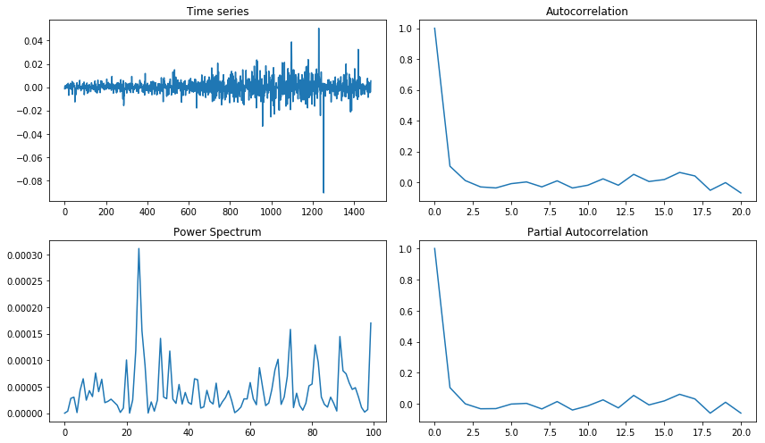

```python
figu = plt.figure(figsize=(12,7))
stats.plot4(fig = figu)
plt.tight_layout()
result = adfuller(crypto_returns_ts[symbolic].values)
print('ADF Statistic: %f' % result[0])
print('p-value: %f' % result[1])
print('Critical Values:')
for key, value in result[4].items():
    print('\t%s: %.3f' % (key, value))
```

```python
from statsmodels.tsa.arima_model import ARIMA
```

```
                             ARIMA Model Results
==============================================================================
Dep. Variable:                 D2.LTC   No. Observations:                 1481
Model:                 ARIMA(5, 2, 0)   Log Likelihood                5001.818
Method:                       css-mle   S.D. of innovations              0.008
Date:                Tue, 22 May 2018   AIC                          -9989.636
Time:                        21:24:31   BIC                          -9952.533
Sample:                    03-05-2018   HQIC                         -9975.805
                         - 02-17-2018
================================================================================
                   coef    std err          z      P>|z|      [0.025      0.975]
--------------------------------------------------------------------------------
const         4.619e-07   3.82e-05      0.012      0.990   -7.44e-05    7.53e-05
ar.L1.D2.LTC    -1.3263      0.025    -53.489      0.000      -1.375      -1.278
ar.L2.D2.LTC    -1.2832      0.039    -33.272      0.000      -1.359      -1.208
ar.L3.D2.LTC    -1.0349      0.043    -23.909      0.000      -1.120      -0.950
ar.L4.D2.LTC    -0.6834      0.039    -17.738      0.000      -0.759      -0.608
ar.L5.D2.LTC    -0.2983      0.025    -12.043      0.000      -0.347      -0.250
                                    Roots
=============================================================================
                 Real           Imaginary           Modulus         Frequency
-----------------------------------------------------------------------------
AR.1            0.3155           -1.2014j            1.2422           -0.2091
AR.2            0.3155           +1.2014j            1.2422            0.2091
AR.3           -1.3099           -0.0000j            1.3099           -0.5000
AR.4           -0.8060           -1.0045j            1.2879           -0.3576
AR.5           -0.8060           +1.0045j            1.2879            0.3576
-----------------------------------------------------------------------------
```

[interactive chart not shown]

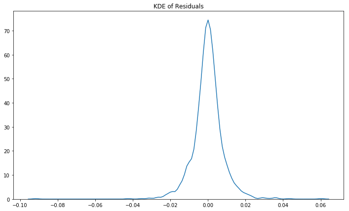

```python
model = ARIMA(crypto_returns_ts[symbolic], order=(5,2,0))
model_fit = model.fit(disp=0)
print(model_fit.summary())

residuals = pd.DataFrame(model_fit.resid)

residuals.iplot(kind='scatter',title = 'Residuals')

plt.figure(figsize=(12,7))

sns.distplot(residuals,hist=False)
plt.title('KDE of Residuals')
plt.show()
```

```python
residuals.describe()
```

|  | 0 |
| --- | --- |
| count | 1481.000000 |
| mean | -0.000003 |
| std | 0.008257 |
| min | -0.091556 |
| 25% | -0.003709 |
| 50% | 0.000017 |
| 75% | 0.003735 |
| max | 0.060253 |

```python
from sklearn.metrics import mean_squared_error
size = int(len(crypto_returns_ts[symbolic]) * 0.66)
train, test = crypto_returns_ts[symbolic][0:size], crypto_returns_ts[symbolic][size:len(crypto_returns_ts[symbolic])]
history = [x for x in train]
predictions = list()
for t in range(10):
    model = ARIMA(history, order=(5,0,0))
    model_fit = model.fit(disp=0)
    output = model_fit.forecast()
    yhat = output[0]
    predictions.append(yhat)
    obs = test[t]
    history.append(obs)
```

```python
pred = []
for i in range(len(predictions)):
    a = predictions[i].tolist()
    pred.append(a[0])
```

```python
error = np.sum(np.square(test[:10].values - pred))
```

```python
print('MSE: ',error/10)
```

```
MSE:  1.6550511134326812e-05
```

```python
sample = pd.DataFrame(test[:10])
sample['pred'] = pred
sample.iplot(kind='scatter')
```

[interactive chart not shown]

## Prediction Method 2: Monte-Carlo Simulations

```python
crypto.sort_index(axis=0,ascending=True,inplace=True)
```

```python
crypto_sim = crypto[symbolic][:10].values
```

```python
price_poss = pd.DataFrame()
```

```python
num_sims = 1000
```

```python
time_frame = 96
```

```python
last_price = crypto_sim[-1]
```

```python
last_price
```

```
226.46099999999998
```

```python
np.random.seed(141)
for i in range(num_sims):
    count = 0
    returns_vol = crypto_returns[symbolic].std()
    price_val = []
    price = last_price
    price_val.append(price)
    for y in range(time_frame):
        if count == 95:
            break
        price = price_val[count] * (1 + np.random.normal(0,returns_vol))
        price_val.append(price)
        count = count + 1

    price_poss[i] = price_val
```

```python
indx = crypto[symbolic][10:(96+10)].index
```

```python
price_poss.set_index(indx,inplace=True)
```

```python
price_poss[symbolic] = crypto[symbolic][10:(96+10)].values
```

```python
price_poss[[symbolic,0,1,2,3,4,5]].iplot(kind='scatter')
```

[interactive chart not shown]

```python
possible_prices = price_poss.iloc[-1,:]
```

```python
from scipy.stats import norm
```

```python
mu, std = norm.fit(possible_prices)
```

```python
np.percentile(possible_prices,[25,75])
```

```
array([216.96001411, 235.92153321])
```

```python
p_25,p_75 = np.percentile(possible_prices,[25,75])
```

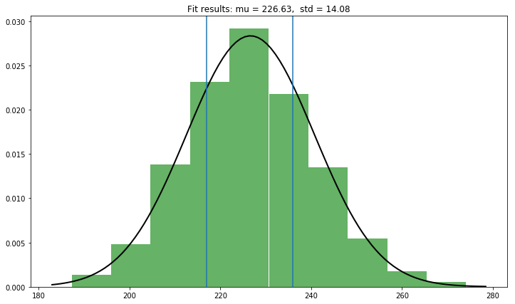

```python
plt.figure(figsize=(12,7))
plt.hist(possible_prices, normed=True, alpha=0.6, color='g')

# Plot the PDF.
xmin, xmax = plt.xlim()
x = np.linspace(xmin, xmax, 100)
p = norm.pdf(x, mu, std)
plt.plot(x, p, 'k', linewidth=2)
title = "Fit results: mu = %.2f,  std = %.2f" % (mu, std)
plt.axvline(p_25)
plt.axvline(p_75)
plt.title(title)

plt.show()
```

```python
print('The Possible Price Lies between: ',p_25,' and ',p_75)
```

```
The Possible Price Lies between:  216.9600141053793  and  235.92153321366897
```